# Exploratory Analysis

## Title

Crime Data Analysis in Seattle

### Authors

Kenta Lipsey klipsey@uw.edu

### Date

5/1/2024 Spring 2024

### Abstract

My main question is, “how does crime data in Seattle change depending on its location/district?” It is important to address this question because it takes a look at the status of Seattle’s crime over time and the factors that come into play.

### Introduction

My project entails a meticulous examination of Seattle’s crime reports, focusing on crime types, details, and locations. By compiling and analyzing this data, I aim to identify crime hotspots and prevalent crime categories, providing valuable insights into the city’s underlying issues. Understanding the root causes behind criminal behavior enables us to adopt proactive measures to address societal problems effectively. Through this data-driven approach, we can work towards creating a safer and more resilient community for all residents.

### Related Work

Crime data analysis is instrumental in understanding, preventing, and responding to criminal activities, benefiting society in various ways. It identifies crime hotspots, enabling law enforcement to allocate resources efficiently and reduce response times, thus deterring criminal behavior. Additionally, it aids in developing evidence-based crime prevention strategies by identifying underlying factors contributing to criminal behavior. This includes socio-economic conditions, environmental factors, and social networks, leading to targeted interventions and safer communities. Moreover, crime data analysis evaluates the effectiveness of criminal justice policies and interventions, guiding resource allocation and policy reforms for more efficient and equitable systems. Overall, crime data analysis serves as a powerful tool for enhancing public safety and well-being. For further exploration, resources such as articles from reputable law enforcement publications, research papers on spatial analysis techniques, and discussions on big data analytics’ potential in crime prevention offer valuable insights into this field.

### The Dataset

https://www.seattle.gov/police/information-and-data/data/public-data-sets I found this data on the seattle.gov website. This data was collected by our government. These data sets are collected and generated by the police whenever an arrest happens. This data was collected in order to keep track of crime data over time in the city of seattle. This also helps law enforcement prioritize specific areas that are more common for crime. There are over 1 million rows and 17 columns. Ethical questions to consider is the idea of predictive policing. In the past, data like this was used in algorithms to “predict” crime before it happens. This would often cause police to interrogate individuals before any indication of crime simply because an algorithm said so. This is highly unethical since the algorithm is bias and will pick people based on features that do not nesscarily indicate their likelyhood of crime. The issues with this data is that it requires an additional dataset to be proper affected. This can include a data set that also maps out zip code areas or locational features so that the crime data can be visualized properly when imported into a data visualizer.

### Implications

If properly examined, this dataset can help people factor in crime when it comes to many decisions. This could be something simple like picking where to live or where to eat next but it can also be scaled to changes in policies within our government. For example, if crime levels are increasing in certain areas that haven’t been maintained (roads, buildings, cleanliness) the government can put funds towards repairing the area. If crime increases in more wealthy locations and the highest crime is theft of some sort, policies to address class issues could be brought up to help those who feel as if they need to resort to crime in order to survive. Crime is an indication of bigger issues in our society and this data should be used to address them instead of bandaging the issue by only arresting those who commit crimes.

### Limitations & Challenges

In the field of crime data analysis, numerous obstacles hinder the extraction of valuable insights. One significant challenge is the varied quality and accessibility of the data, stemming from its diverse sources and formats. This necessitates a thorough and resource-intensive process of integrating and cleaning datasets, requiring meticulous attention to detail. Additionally, maintaining data privacy standards is crucial, particularly considering the sensitive nature of the information involved. Furthermore, biases present in both analysis and decision-making pose a significant barrier. These biases may arise from historical disparities in law enforcement practices or inherent flaws in data collection methodologies. Overcoming these biases requires a dedicated focus on fairness, transparency, and accountability throughout the analytical process. To fully realize the potential of crime data analysis for societal benefit, it is imperative to invest in robust methodologies that effectively mitigate biases while ensuring the accuracy and fairness of the results. By confronting these challenges directly, stakeholders can pave the way for more impactful crime prevention strategies and contribute to building a safer and more just society overall.

### Summary Information

After my summary information analysis, I was surprised to see the most frequent offense for crime and the most reported crime year. I expected the highest crime to be theft but seeing that motor theft was the most popular was not something I thought would be the case with Seattle being quite difficult to navigate by car. I was also surprised by the highest crime year being 2020 since that was the peak time of lock down for America. It does make sense that it was though because it was a time where many jobs were lost.

### Table

I made this table to map out the highest crime locations since this is a big factor when it comes to peoples consideration of navigating Seattle. It reveals that Downtown is the highest crime rate location in Seattle which is something not too unexpected.

```
## # A tibble: 60 × 3
##    Location                 Offenses_Reported Highest_Type_Of_Offense_Committed
##    <chr>                                <int> <chr>
##  1 CASE/CASCAD                              1 Theft From Motor Vehicle
##  2 COMMERCIAL HARBOR ISLAND               423 Theft From Motor Vehicle
##  3 COMMERCIAL DUWAMISH                    767 Theft From Motor Vehicle
##  4 PIGEON POINT                          1362 Theft From Motor Vehicle
##  5 EASTLAKE - EAST                       1761 Theft From Motor Vehicle
##  6 GENESEE                               3484 Theft From Motor Vehicle
##  7 MADISON PARK                          3778 Theft From Motor Vehicle
##  8 SOUTH DELRIDGE                        4537 Theft From Motor Vehicle
##  9 FAUNTLEROY SW                         4678 Theft From Motor Vehicle
## 10 SOUTH BEACON HILL                     4913 Theft From Motor Vehicle
## # ℹ 50 more rows
```

### Chart 1

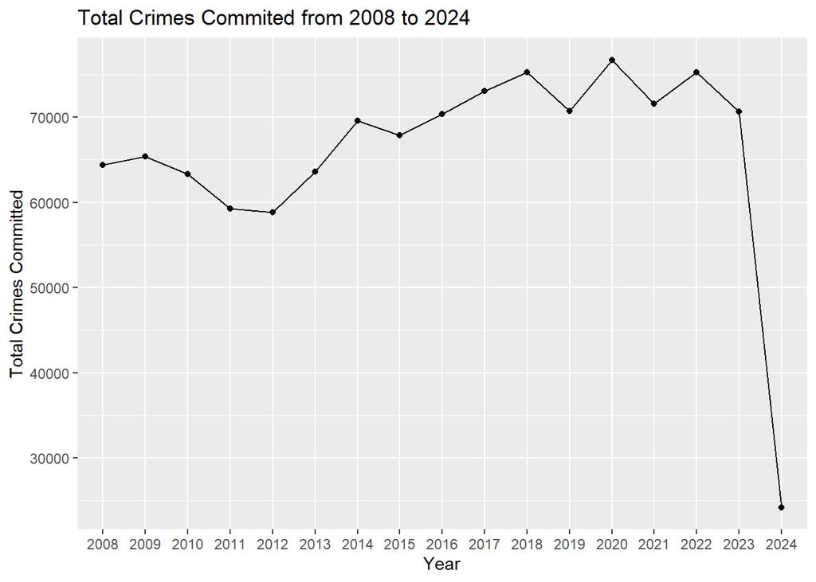

### Chart 2

I made this chart to see which locations had the highest crime rate. This can help people understand what locations to avoid if they are looking to travel safely through Seattle. It can also help police officers effectively spread out across the city.

[figure not shown]

### Chart 3

I made this chart to visualize the amount of unique crimes committed in Seattle. From this data we can see that theft or destruction of property sit at the top of the list. This shows that a majority of our crime could potentially be from class based issues in our society.

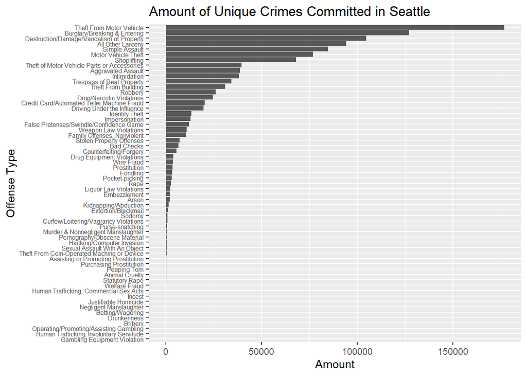